# Regression Models

Achmad Gunar Saadi

August 4, 2018

# 1 Introduction

## 1.1 Objectives

**Project: Regression Models**

Write a regression analysis report. Using the dataset provided by you, write your findings on the different socioeconomics variables most highly correlated to crime rates (**crime_rate**). Explain the recommendations where appropriate. As guidance, ask the following questions of your candidate model:

- Can your model be any more simplified without losing substantial information?
- Have you tried predicting the crime rate given a reasonable set of values for the predictor variable?
- Have you identified any non-random pattern in your residual plot?

The model has to answer the indicators as follow:  
1. The model achieves an adjusted R-squared value above the grading threshold of 0.701  
2. The residual plot resembles a random scatterplot

## 1.2 Read and understand the Dataset

This is how the data look like (I only display the first 10 data). I also rename the variable names, to get more explaining names.

```r
library(dplyr)
crime <- read.csv("./crime.csv") %>% dplyr::select(-X)
names(crime) <- c("percent_m", "is_south", "mean_education", "police_exp60", "police_exp59", "labour_participation", "m_per1000f", "state_pop", "nonwhites_per1000", "unemploy_m24", "unemploy_m39", "gdp", "inequality", "prob_prison", "time_prison", "crime_rate")
head(crime,10)
```

```
##    percent_m is_south mean_education police_exp60 police_exp59
## 1        151        1             91           58           56
## 2        143        0            113          103           95
## 3        142        1             89           45           44
## 4        136        0            121          149          141
## 5        141        0            121          109          101
## 6        121        0            110          118          115
## 7        127        1            111           82           79
## 8        131        1            109          115          109
## 9        157        1             90           65           62
## 10       140        0            118           71           68
##    labour_participation m_per1000f state_pop nonwhites_per1000
## 1                   510        950        33               301
## 2                   583       1012        13               102
## 3                   533        969        18               219
```

[output cut: 29 more lines]

## 1.3 Data Explanation

As mentioned in the **Read and understand the Dataset** section, I rename the variable names, so that easier to remember.  
Dataset was collected in 1960. There are 16 variables inside of the dataset. Those variables are as follow:

- **M** renamed to **percent_m** — percentage of males aged 14-24
- **So** renamed to **is_south: whether** — whether it is in a Southern state. 1 for Yes, 0 for No.
- **Ed** renamed to **mean_education** — mean years of schooling
- **Po1** renamed to **police_exp60** — police expenditure in 1960
- **Po2** renamed to **police_exp59** — police expenditure in 1959
- **LF** renamed to **labour_participation** — labour force participation rate
- **M.F** renamed to **m_per1000f** — number of males per 1000 females
- **Pop** renamed to **state_pop** — state population
- **NW** renamed to **nonwhites_per1000** — number of non-whites resident per 1000 people
- **U1** renamed to **unemploy_m24** — unemployment rate of urban males aged 14-24
- **U2**renamed to **unemploy_m39** — unemployment rate of urban males aged 35-39
- **GDP** renamed to **gdp** — gross domestic product per head
- **Ineq** renamed to **inequality** — income inequality
- **Prob** renamed to **prob_prison** — probability of imprisonment
- **Time** renamed to **time_prison** — avg time served in prisons
- **y** renamed to **crime_rate** — crime rate in an unspecified category

# 2 Exploring the Data

## 2.1 Quick Look the data

For the first insight, let’s quick-look the scatterplot, check the relationship (correlation) of each variables with respect to crime rate, and the impact of the variables with crime rate by their gradient values.

```r
library(GGally)
```

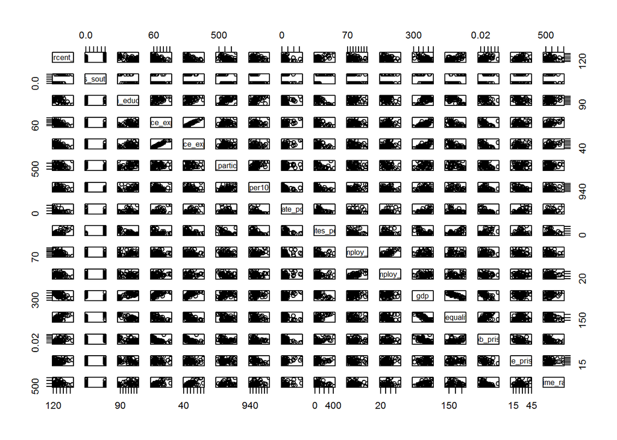

```r
pairs(crime)
```

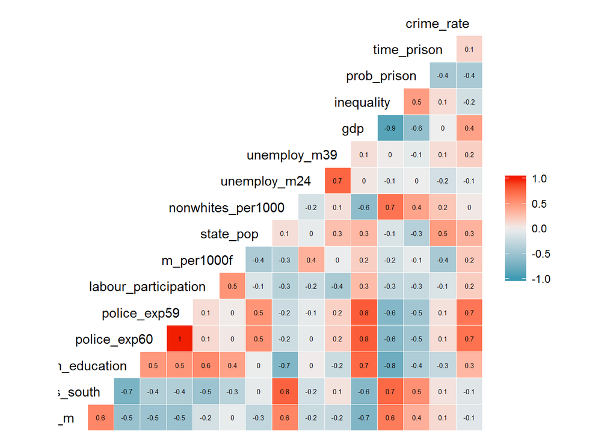

```r
ggcorr(crime, label = T,label_size = 2, hjust=1)
```

```r
summary(lm(crime_rate~.,crime))
```

```
##
## Call:
## lm(formula = crime_rate ~ ., data = crime)
##
## Residuals:
##     Min      1Q  Median      3Q     Max
## -395.74  -98.09   -6.69  112.99  512.67
##
## Coefficients:
##                        Estimate Std. Error t value Pr(>|t|)
## (Intercept)          -5984.2876  1628.3184  -3.675 0.000893 ***
## percent_m                8.7830     4.1714   2.106 0.043443 *
## is_south                -3.8035   148.7551  -0.026 0.979765
## mean_education          18.8324     6.2088   3.033 0.004861 **
## police_exp60            19.2804    10.6110   1.817 0.078892 .
## police_exp59           -10.9422    11.7478  -0.931 0.358830
## labour_participation    -0.6638     1.4697  -0.452 0.654654
## m_per1000f               1.7407     2.0354   0.855 0.398995
## state_pop               -0.7330     1.2896  -0.568 0.573845
## nonwhites_per1000        0.4204     0.6481   0.649 0.521279
## unemploy_m24            -5.8271     4.2103  -1.384 0.176238
## unemploy_m39            16.7800     8.2336   2.038 0.050161 .
## gdp                      0.9617     1.0367   0.928 0.360754
## inequality               7.0672     2.2717   3.111 0.003983 **
## prob_prison          -4855.2658  2272.3746  -2.137 0.040627 *
## time_prison             -3.4790     7.1653  -0.486 0.630708
## ---
## Signif. codes:  0 '***' 0.001 '**' 0.01 '*' 0.05 '.' 0.1 ' ' 1
##
## Residual standard error: 209.1 on 31 degrees of freedom
## Multiple R-squared:  0.8031, Adjusted R-squared:  0.7078
## F-statistic: 8.429 on 15 and 31 DF,  p-value: 3.539e-07
```

Several of those variables are confirmed by the value of ggcor() function result, as follow:  
+ police_exp60 (0.7)  
+ police_exp59 (0.7)  
+ gdp (0.4)  
+ state_pop (0.3)  
+ mean_education (0.3)  
+ prob_prison(-0.4)

## 2.2 Feature Selection

After that, we will try to select the proper features from now on using stepwise regression. The AIC determine which independent variables that can altogether give significant impact to the model (the least AIC the better).

```r
# backward elimination
lin.all <- lm(crime_rate ~., crime)
step(lin.all, direction="backward")
```

```
## Start:  AIC=514.65
## crime_rate ~ percent_m + is_south + mean_education + police_exp60 +
##     police_exp59 + labour_participation + m_per1000f + state_pop +
##     nonwhites_per1000 + unemploy_m24 + unemploy_m39 + gdp + inequality +
##     prob_prison + time_prison
##
##                        Df Sum of Sq     RSS    AIC
## - is_south              1        29 1354974 512.65
## - labour_participation  1      8917 1363862 512.96
## - time_prison           1     10304 1365250 513.00
## - state_pop             1     14122 1369068 513.14
## - nonwhites_per1000     1     18395 1373341 513.28
## - m_per1000f            1     31967 1386913 513.74
## - gdp                   1     37613 1392558 513.94
## - police_exp59          1     37919 1392865 513.95
## <none>                              1354946 514.65
## - unemploy_m24          1     83722 1438668 515.47
## - police_exp60          1    144306 1499252 517.41
## - unemploy_m39          1    181536 1536482 518.56
## - percent_m             1    193770 1548716 518.93
## - prob_prison           1    199538 1554484 519.11
## - mean_education        1    402117 1757063 524.86
## - inequality            1    423031 1777977 525.42
##
## Step:  AIC=512.65
## crime_rate ~ percent_m + mean_education + police_exp60 + police_exp59 +
##     labour_participation + m_per1000f + state_pop + nonwhites_per1000 +
##     unemploy_m24 + unemploy_m39 + gdp + inequality + prob_prison +
##     time_prison
##
##                        Df Sum of Sq     RSS    AIC
## - time_prison           1     10341 1365315 511.01
## - labour_participation  1     10878 1365852 511.03
## - state_pop             1     14127 1369101 511.14
## - nonwhites_per1000     1     21626 1376600 511.39
## - m_per1000f            1     32449 1387423 511.76
## - police_exp59          1     37954 1392929 511.95
## - gdp                   1     39223 1394197 511.99
## <none>                              1354974 512.65
## - unemploy_m24          1     96420 1451395 513.88
```

[output cut: 100 more lines]

```
##
## Step:  AIC=503.93
## crime_rate ~ percent_m + mean_education + police_exp60 + m_per1000f +
##     unemploy_m24 + unemploy_m39 + inequality + prob_prison
##
##                  Df Sum of Sq     RSS    AIC
## <none>                        1453068 503.93
## - m_per1000f      1    103159 1556227 505.16
## - unemploy_m24    1    127044 1580112 505.87
## - prob_prison     1    247978 1701046 509.34
## - unemploy_m39    1    255443 1708511 509.55
## - percent_m       1    296790 1749858 510.67
## - mean_education  1    445788 1898855 514.51
## - inequality      1    738244 2191312 521.24
## - police_exp60    1   1672038 3125105 537.93
```

```
##
## Call:
## lm(formula = crime_rate ~ percent_m + mean_education + police_exp60 +
##     m_per1000f + unemploy_m24 + unemploy_m39 + inequality + prob_prison,
##     data = crime)
##
## Coefficients:
##    (Intercept)       percent_m  mean_education    police_exp60
##      -6426.101           9.332          18.012          10.265
##     m_per1000f    unemploy_m24    unemploy_m39      inequality
##          2.234          -6.087          18.735           6.133
##    prob_prison
##      -3796.032
```

```r
# Foward elimination
lin.none <- lm(crime_rate ~ 1, crime)
step(lin.none, scope=list( lower=lin.none,upper=lin.all), direction="forward")
```

```
## Start:  AIC=561.02
## crime_rate ~ 1
##
##                        Df Sum of Sq     RSS    AIC
## + police_exp60          1   3253302 3627626 532.94
## + police_exp59          1   3058626 3822302 535.39
## + gdp                   1   1340152 5540775 552.84
## + prob_prison           1   1257075 5623853 553.54
## + state_pop             1    783660 6097267 557.34
## + mean_education        1    717146 6163781 557.85
## + m_per1000f            1    314867 6566061 560.82
## <none>                              6880928 561.02
## + labour_participation  1    245446 6635482 561.32
## + inequality            1    220530 6660397 561.49
## + unemploy_m39          1    216354 6664573 561.52
## + time_prison           1    154545 6726383 561.96
## + is_south              1     56527 6824400 562.64
## + percent_m             1     55084 6825844 562.65
## + unemploy_m24          1     17533 6863395 562.90
## + nonwhites_per1000     1      7312 6873615 562.97
##
## Step:  AIC=532.94
## crime_rate ~ police_exp60
##
##                        Df Sum of Sq     RSS    AIC
## + inequality            1    739819 2887807 524.22
## + percent_m             1    616741 3010885 526.18
## + m_per1000f            1    250522 3377104 531.57
## + nonwhites_per1000     1    232434 3395192 531.82
## + is_south              1    219098 3408528 532.01
## + gdp                   1    180872 3446754 532.53
## <none>                              3627626 532.94
## + police_exp59          1    146167 3481459 533.00
## + prob_prison           1     92278 3535348 533.72
## + labour_participation  1     77479 3550147 533.92
## + time_prison           1     43185 3584441 534.37
## + unemploy_m39          1     17848 3609778 534.70
## + state_pop             1      5666 3621959 534.86
## + unemploy_m24          1      2878 3624748 534.90
## + mean_education        1       767 3626859 534.93
```

[output cut: 72 more lines]

```
## Step:  AIC=504.79
## crime_rate ~ police_exp60 + inequality + mean_education + percent_m +
##     prob_prison + unemploy_m39
##
##                        Df Sum of Sq     RSS    AIC
## <none>                              1611057 504.79
## + gdp                   1     59910 1551147 505.00
## + unemploy_m24          1     54830 1556227 505.16
## + state_pop             1     51320 1559737 505.26
## + m_per1000f            1     30945 1580112 505.87
## + police_exp59          1     25017 1586040 506.05
## + is_south              1     17958 1593098 506.26
## + labour_participation  1     13179 1597878 506.40
## + time_prison           1      7159 1603898 506.58
## + nonwhites_per1000     1       359 1610698 506.78
```

```
##
## Call:
## lm(formula = crime_rate ~ police_exp60 + inequality + mean_education +
##     percent_m + prob_prison + unemploy_m39, data = crime)
##
## Coefficients:
##    (Intercept)    police_exp60      inequality  mean_education
##      -5040.505          11.502           6.765          19.647
##      percent_m     prob_prison    unemploy_m39
##         10.502       -3801.836           8.937
```

```r
# Both side elimination
step(lin.none, scope = list(lower=lin.none,upper=lin.all), data=crime, direction="both")
```

```
## Start:  AIC=561.02
## crime_rate ~ 1
##
##                        Df Sum of Sq     RSS    AIC
## + police_exp60          1   3253302 3627626 532.94
## + police_exp59          1   3058626 3822302 535.39
## + gdp                   1   1340152 5540775 552.84
## + prob_prison           1   1257075 5623853 553.54
## + state_pop             1    783660 6097267 557.34
## + mean_education        1    717146 6163781 557.85
## + m_per1000f            1    314867 6566061 560.82
## <none>                              6880928 561.02
## + labour_participation  1    245446 6635482 561.32
## + inequality            1    220530 6660397 561.49
## + unemploy_m39          1    216354 6664573 561.52
## + time_prison           1    154545 6726383 561.96
## + is_south              1     56527 6824400 562.64
## + percent_m             1     55084 6825844 562.65
## + unemploy_m24          1     17533 6863395 562.90
## + nonwhites_per1000     1      7312 6873615 562.97
##
## Step:  AIC=532.94
## crime_rate ~ police_exp60
##
##                        Df Sum of Sq     RSS    AIC
## + inequality            1    739819 2887807 524.22
## + percent_m             1    616741 3010885 526.18
## + m_per1000f            1    250522 3377104 531.57
## + nonwhites_per1000     1    232434 3395192 531.82
## + is_south              1    219098 3408528 532.01
## + gdp                   1    180872 3446754 532.53
## <none>                              3627626 532.94
## + police_exp59          1    146167 3481459 533.00
## + prob_prison           1     92278 3535348 533.72
## + labour_participation  1     77479 3550147 533.92
## + time_prison           1     43185 3584441 534.37
## + unemploy_m39          1     17848 3609778 534.70
## + state_pop             1      5666 3621959 534.86
## + unemploy_m24          1      2878 3624748 534.90
## + mean_education        1       767 3626859 534.93
```

[output cut: 93 more lines]

```
## + gdp                   1     59910 1551147 505.00
## + unemploy_m24          1     54830 1556227 505.16
## + state_pop             1     51320 1559737 505.26
## + m_per1000f            1     30945 1580112 505.87
## + police_exp59          1     25017 1586040 506.05
## + is_south              1     17958 1593098 506.26
## + labour_participation  1     13179 1597878 506.40
## + time_prison           1      7159 1603898 506.58
## + nonwhites_per1000     1       359 1610698 506.78
## - unemploy_m39          1    192233 1803290 508.08
## - prob_prison           1    249308 1860365 509.55
## - percent_m             1    400611 2011667 513.22
## - mean_education        1    776207 2387264 521.27
## - inequality            1    949221 2560278 524.56
## - police_exp60          1   2817067 4428124 550.31
```

```
##
## Call:
## lm(formula = crime_rate ~ police_exp60 + inequality + mean_education +
##     percent_m + prob_prison + unemploy_m39, data = crime)
##
## Coefficients:
##    (Intercept)    police_exp60      inequality  mean_education
##      -5040.505          11.502           6.765          19.647
##      percent_m     prob_prison    unemploy_m39
##         10.502       -3801.836           8.937
```

As we get the least average AIC by using the **backward elimination method**, thus we go on using the result from it. The variable that selected from this method is:  
+ m_per1000f  
+ unemploy_m24  
+ prob_prison  
+ unemploy_m39  
+ percent_m  
+ mean_education + inequality  
+ police_exp60

## 2.3 Variables to focus

From the quick look and feature selection, I suggest we may focus on these variables:  
+ police_exp60 + unemploy_m39 + mean_education  
+ prob_prison + inequality + percent_m

Summary of the regression model using these variable as below:

```r
summary(lm(crime_rate~police_exp60+unemploy_m39+mean_education+prob_prison+inequality+percent_m,crime))
```

```
##
## Call:
## lm(formula = crime_rate ~ police_exp60 + unemploy_m39 + mean_education +
##     prob_prison + inequality + percent_m, data = crime)
##
## Residuals:
##     Min      1Q  Median      3Q     Max
## -470.68  -78.41  -19.68  133.12  556.23
##
## Coefficients:
##                 Estimate Std. Error t value Pr(>|t|)
## (Intercept)    -5040.505    899.843  -5.602 1.72e-06 ***
## police_exp60      11.502      1.375   8.363 2.56e-10 ***
## unemploy_m39       8.937      4.091   2.185  0.03483 *
## mean_education    19.647      4.475   4.390 8.07e-05 ***
## prob_prison    -3801.836   1528.097  -2.488  0.01711 *
## inequality         6.765      1.394   4.855 1.88e-05 ***
## percent_m         10.502      3.330   3.154  0.00305 **
## ---
## Signif. codes:  0 '***' 0.001 '**' 0.01 '*' 0.05 '.' 0.1 ' ' 1
##
## Residual standard error: 200.7 on 40 degrees of freedom
## Multiple R-squared:  0.7659, Adjusted R-squared:  0.7307
## F-statistic: 21.81 on 6 and 40 DF,  p-value: 3.418e-11
```

The R-squared value is **0.7659** and adjusted R-squared is **0.7307** by using the selected variables.

## 2.4 Residual Plot

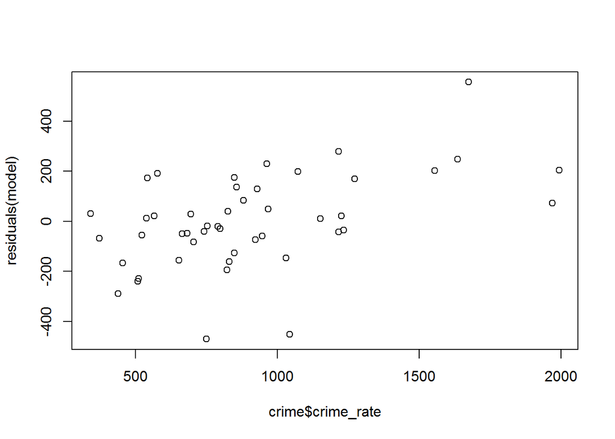

```r
model <- lm(formula = crime_rate~police_exp60+unemploy_m39+mean_education+prob_prison+inequality+percent_m,data = crime)
plot(crime$crime_rate,residuals(model))
```

## 2.5 Predicting Crime Rate

```r
# Predicting crime rate
# data.before will be the data reference.
# data.after.exp --> variation data by increasing significantly the police_exp60, while other variables remain
# data.after.prob --> variation data by increasing significantly the prob_prison, while other variables remain
data.before<-data.frame(police_exp60=100,unemploy_m39=70,mean_education=128,prob_prison=0.08,inequality=260,percent_m=150)
data.after.exp<-data.frame(police_exp60=300,unemploy_m39=70,mean_education=128,prob_prison=0.08,inequality=260,percent_m=150)
data.after.prob<-data.frame(police_exp60=100,unemploy_m39=70,mean_education=128,prob_prison=0.1,inequality=260,percent_m=150)
predict(model,data.before)
```

```
##        1
## 2280.261
```

```r
predict(model,data.after.exp)
```

```
##        1
## 4580.745
```

```r
predict(model,data.after.prob)
```

```
##        1
## 2204.224
```

The variable data.before become the reference value. While from variable data.after.exp we can tell that the increasing of police_exp60 will affect the increasing of crime rate. On the other hand, the increasing of prob_prison affect the decreasing of crime rate just like described by data.after.prob variable.

# 3 Conclusion

Recall the objectives of the assignment:  
* Can your model be any more simplified without losing substantial information?  
* Have you tried predicting the crime rate given a reasonable set of values for the predictor variable?  
* Have you identified any non-random pattern in your residual plot?